# Evaluating the effect of pair selection schemes on performance

Artem Sokolov

We compare the following pair selection schemes:

- `Current` - “Current” scheme that performs no minimization and simply composes a set of pairs, such that each sample is used in at least one pair.
- `All-pairs` - all possible pairs where the samples have different class labels.
- `AOD-all` - each pair is selected such that AOD distance between the two samples is minimized; in case of ties, all possible pairs are considered.
- `AOD-one` - each pair is again selected such that AOD distance is minimized; however, in case of ties, a single pair is selected at random.
- `ID-reuse` - pairs are selected such that the number of times each sample is reused is minimized. The scheme still ensures that each sample is represented at least once.

All predictors are constructed on the ROSMAP dataset, comparing A against C and looking at class calls (rather than probabilities) during pair ranking.

## Performance summary

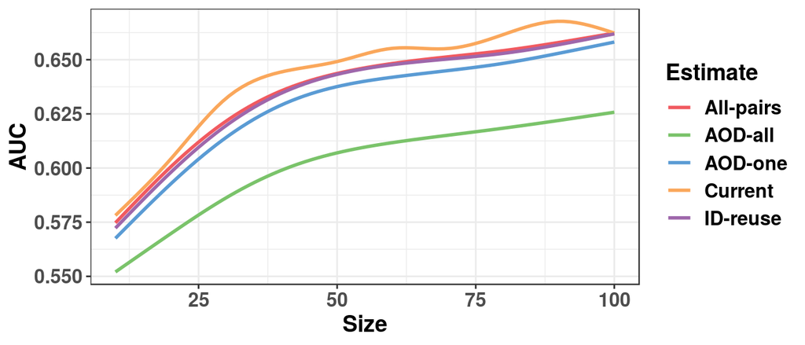

We begin by looking at how the performance changes on background sets. The distinct loss of performance in `AOD-all` suggests that the evaluation scheme is too focused on the “90+” patient subset, where a large number of ties is present.

## ID usage

| Estimate | nPairs |
| --- | --- |
| All-pairs | 15456 |
| AOD-all | 1619 |
| AOD-one | 250 |
| Current | 250 |
| ID-reuse | 250 |

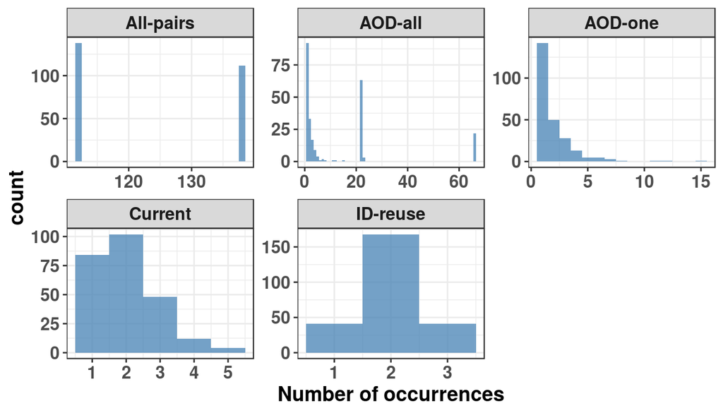

The table shows the total number of pairs considered by each individual pair selection scheme. Interestingly, `AOD-one`, `Current` and `ID-reuse` all produce a set of 250 pairs. `AOD-all` contains many more pairs; again, this is likely due to a large number of ties among the “90+” samples.

The figure shows the number of pairs that each sample ID participates in. As expected, `All-pairs` contains two distinct peaks: all “A” samples are considered `#C` times and all “C” samples are considered `#A` times. `ID-reuse` correctly minimizes the number of times each sample is reused, with all samples being considered by no more than three pairs each. `AOD-all` appears as a superimposition of `AOD-one` (which corresponds to the non-“90+” subset) and the two-peak distribution that is association with the all possible A-vs-C pairs of the “90+” subset.

## Distribution of AOD across pairs

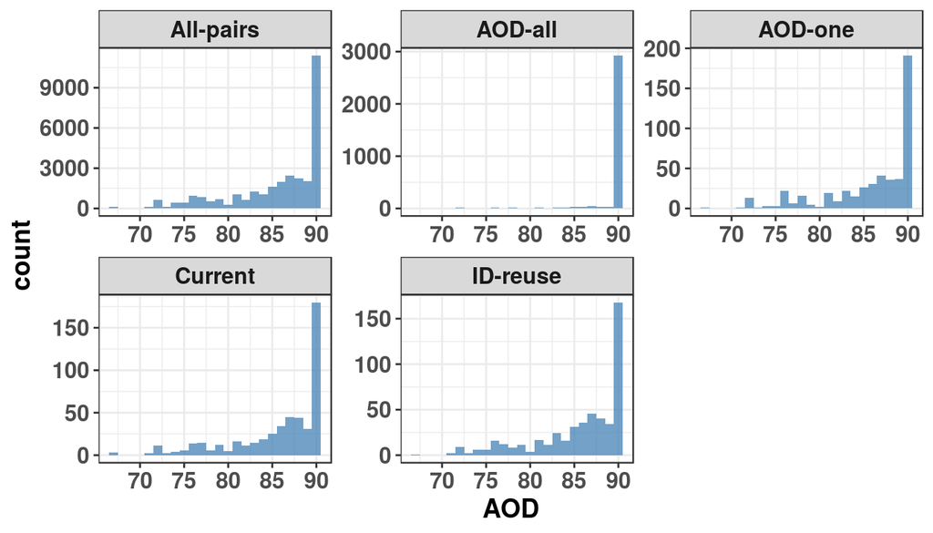

The plot above shows that each scheme generally captures the same distribution of ages across all samples that it considers. The only exception is `AOD-all`, which disproportionately samples from the “90+” category.

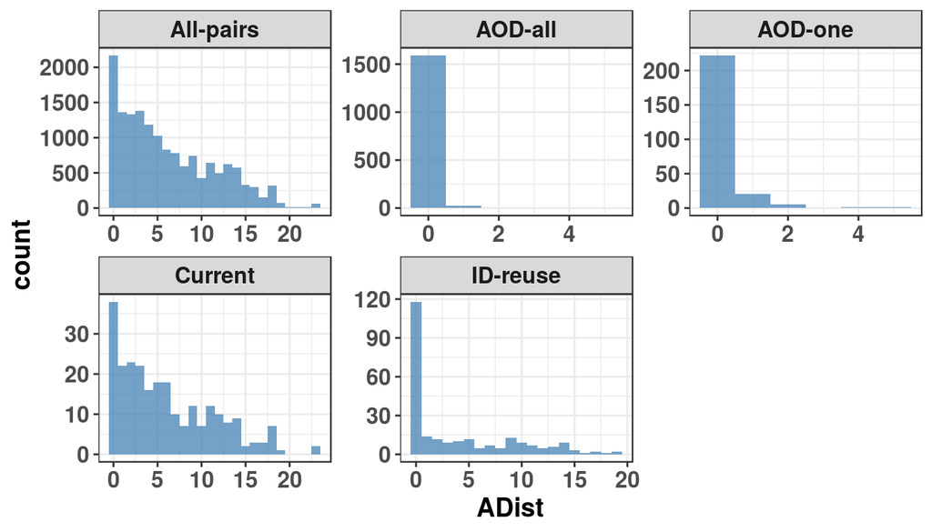

The plot above shows the distribution of age distances (computed as `abs( AOD[1] - AOD[2] )`, where `1` and `2` index the samples in the pair) captured by each pair selection scheme. The plot demonstrates that `AOD-all` and `AOD-one` correctly minimize the `AOD` distance between corresponding pairs of samples.

## Performance estimates for Braak and AOD

| Estimate | Cor |
| --- | --- |
| All-pairs | 1.0000000 |
| AOD-all | 1.0000000 |
| AOD-one | 1.0000000 |
| Current | 0.9999591 |
| ID-reuse | 1.0000000 |

We used information from the `Runs/` directories (https://www.synapse.org/#!Synapse:syn12299033) to compute performance estimates for Braak and AOD columns. The computations were done using the same R code for both variables. As a positive control, we compared Braak performance estimates against BTR-derived estimates, where we observed a near-perfect correspondence (computed as Pearson correlation) between all values in each pair selection scheme.

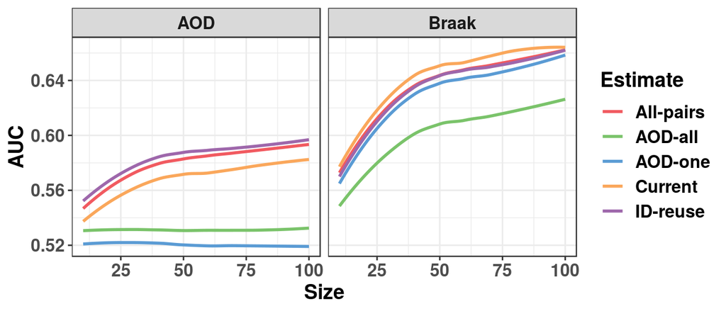

The figure demonstrates that the `AOD-*` pair selection schemes correctly reduce the confounding effect of `AOD` in performance estimates. Going forward, we suggest using `AOD-one` as the main selection scheme, as it leads to the lowest estimate of `AOD` prediction performance (where lower values are more desirable) at the expense of minor decrease in `Braak` performance estimates (where higher values are more desirable). An additional observation is that `ID-reuse` seems to approximate `All-pairs` the closest; in the absence of confounding factors, this scheme might be the best choice for subsampling the space of all pairs.